```r
getwd()
```

```
## [1] "C:/Users/ifeom/OneDrive/Old Drive/Desktop/Project/Publish"
```

```r
EUR_USD_dataset = read.csv("Forex Dataset.csv") # historical EUR/USD dataset
```

```r
library(dplyr) # A grammar library for data manipulation
EUR_USD_dataset = EUR_USD_dataset %>%
  rename(
    TICKVOLUME = TICKVOL,
    VOLUME = VOL
    )

View(EUR_USD_dataset)
```

- 1.01. Adding Simple Moving Average(SMA) Trend indicator

```r
library(quantmod)#A Library For Quantitative Financial Modelling
library(TTR)
#Simple moving average (SMA)
sma <-SMA(Op(EUR_USD_dataset),from='2018-03-01',to='2022-03-01')
EUR_USD_dataset$smaOPEN <- SMA(Op(EUR_USD_dataset),from='2018-03-01',to='2022-03-01')#for OPENING Price
sma <-SMA(Cl(EUR_USD_dataset),from='2018-03-01',to='2022-03-01')
EUR_USD_dataset$smaCLOSE <- SMA(Cl(EUR_USD_dataset),from='2018-03-01',to='2022-03-01')#for CLOSING Price
sma <-SMA(Hi(EUR_USD_dataset),from='2018-03-01',to='2022-03-01')
EUR_USD_dataset$smaHIGH <- SMA(Hi(EUR_USD_dataset),from='2018-03-01',to='2022-03-01')#for HIGH Price
sma <-SMA(Lo(EUR_USD_dataset),from='2018-03-01',to='2022-03-01')
EUR_USD_dataset$smaLOW <- SMA(Lo(EUR_USD_dataset),from='2018-03-01',to='2022-03-01')#for LOW Price
View(EUR_USD_dataset)
```

- 1.01. Check for missing values (NA’s) in the records using the summary function.
- 1.02. Use Data Explorer packages to further analyze records.

```r
summary(EUR_USD_dataset)
```

```
##      DATE                OPEN            HIGH            LOW
##  Length:1038        Min.   :1.066   Min.   :1.081   Min.   :1.064
##  Class :character   1st Qu.:1.121   1st Qu.:1.125   1st Qu.:1.119
##  Mode  :character   Median :1.145   Median :1.148   Median :1.140
##                     Mean   :1.152   Mean   :1.156   Mean   :1.149
##                     3rd Qu.:1.182   3rd Qu.:1.185   3rd Qu.:1.178
##                     Max.   :1.244   Max.   :1.248   Max.   :1.238
##
##      CLOSE         TICKVOLUME         VOLUME      SPREAD        BULL_BEAR
##  Min.   :1.066   Min.   : 10530   Min.   :0   Min.   :0.000   Min.   :0.0000
##  1st Qu.:1.121   1st Qu.: 48830   1st Qu.:0   1st Qu.:0.000   1st Qu.:0.0000
##  Median :1.144   Median : 60694   Median :0   Median :1.000   Median :0.0000
##  Mean   :1.152   Mean   : 66613   Mean   :0   Mean   :1.133   Mean   :0.4942
##  3rd Qu.:1.182   3rd Qu.: 78006   3rd Qu.:0   3rd Qu.:2.000   3rd Qu.:1.0000
##  Max.   :1.244   Max.   :244937   Max.   :0   Max.   :8.000   Max.   :1.0000
##
##     smaOPEN         smaCLOSE        smaHIGH          smaLOW
##  Min.   :1.083   Min.   :1.083   Min.   :1.086   Min.   :1.079
##  1st Qu.:1.123   1st Qu.:1.122   1st Qu.:1.126   1st Qu.:1.119
##  Median :1.144   Median :1.144   Median :1.148   Median :1.140
##  Mean   :1.152   Mean   :1.152   Mean   :1.156   Mean   :1.149
##  3rd Qu.:1.182   3rd Qu.:1.182   3rd Qu.:1.185   3rd Qu.:1.178
##  Max.   :1.235   Max.   :1.235   Max.   :1.239   Max.   :1.231
##  NA's   :9       NA's   :9       NA's   :9       NA's   :9
```

```r
library(DataExplorer) # A library to automate visual exploration of data
```

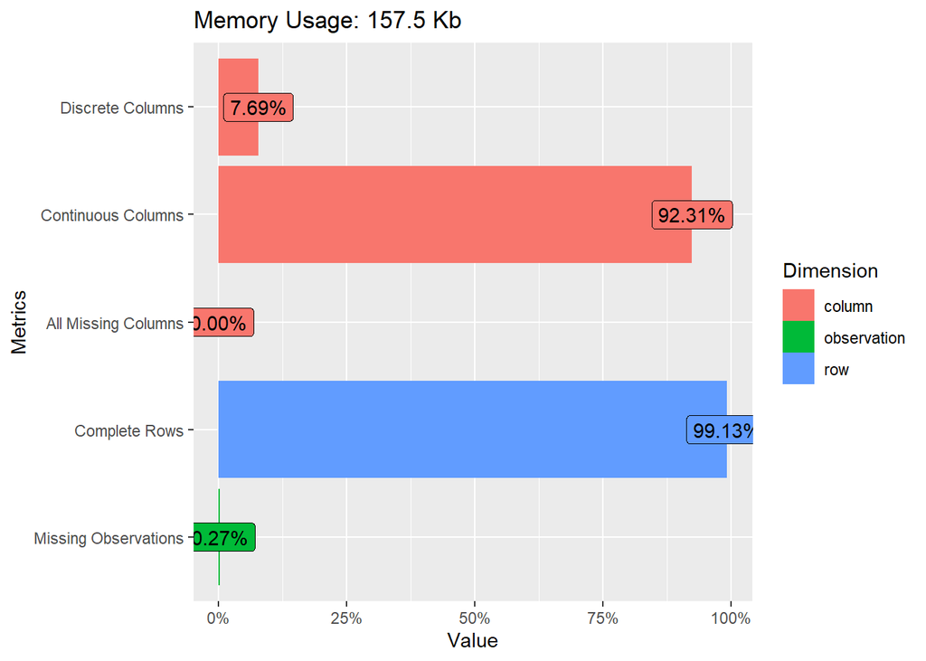

```r
plot_intro(EUR_USD_dataset)
```

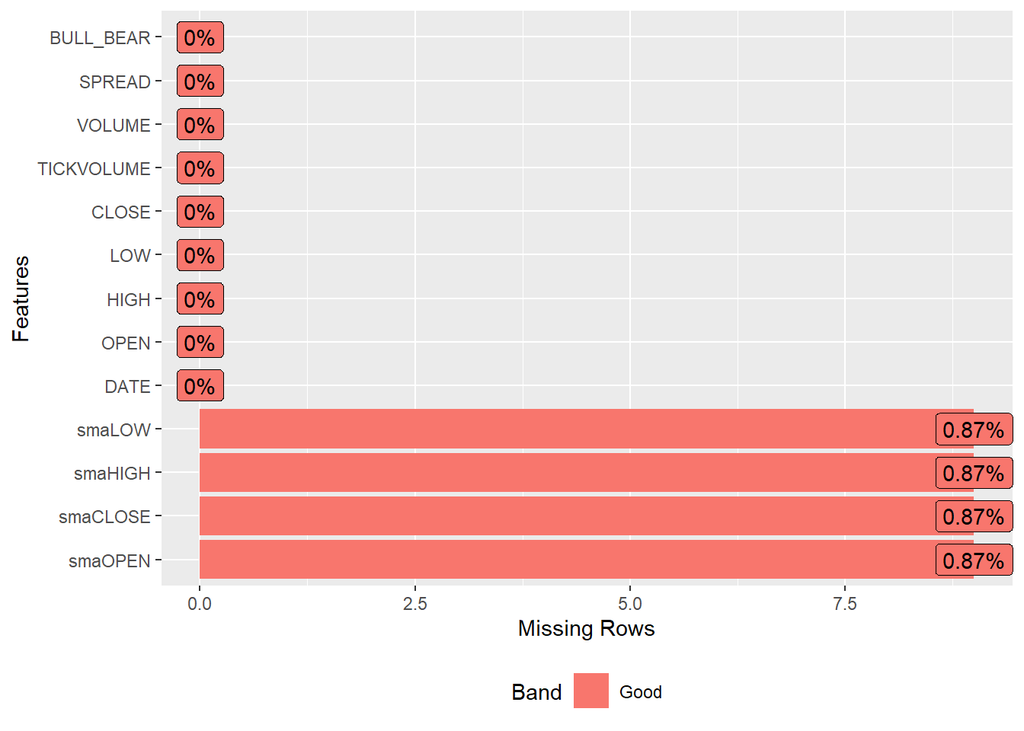

```r
plot_missing(EUR_USD_dataset)
```

```r
library(mice) # A library for Multivariate Imputation by Chained Equations
```

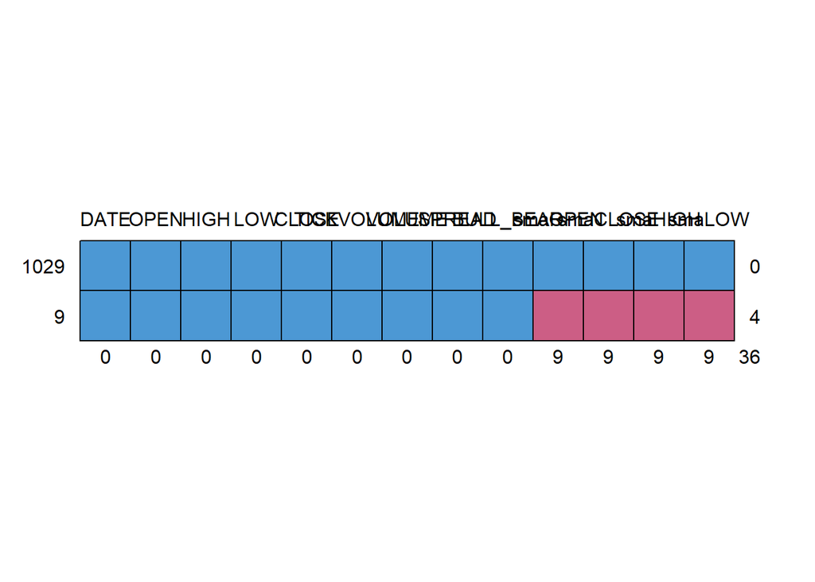

```
##      DATE OPEN HIGH LOW CLOSE TICKVOLUME VOLUME SPREAD BULL_BEAR smaOPEN
## 1029    1    1    1   1     1          1      1      1         1       1
## 9       1    1    1   1     1          1      1      1         1       0
##         0    0    0   0     0          0      0      0         0       9
##      smaCLOSE smaHIGH smaLOW
## 1029        1       1      1  0
## 9           0       0      0  4
##             9       9      9 36
```

```r
md.pattern(EUR_USD_dataset)
```

```r
mice_imputes = mice(EUR_USD_dataset, m = 20, maxit = 40, seed = 10)
mice_imputes$method
```

```
##       DATE       OPEN       HIGH        LOW      CLOSE TICKVOLUME     VOLUME
##         ""         ""         ""         ""         ""         ""         ""
##     SPREAD  BULL_BEAR    smaOPEN   smaCLOSE    smaHIGH     smaLOW
##         ""         ""      "pmm"         ""         ""         ""
```

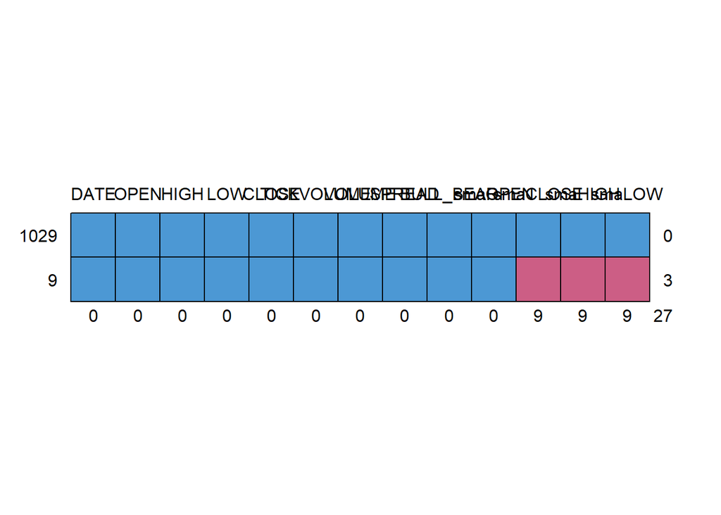

```
##      DATE OPEN HIGH LOW CLOSE TICKVOLUME VOLUME SPREAD BULL_BEAR smaOPEN
## 1029    1    1    1   1     1          1      1      1         1       1
## 9       1    1    1   1     1          1      1      1         1       1
##         0    0    0   0     0          0      0      0         0       0
##      smaCLOSE smaHIGH smaLOW
## 1029        1       1      1  0
## 9           0       0      0  3
##             9       9      9 27
```

```r
EUR_USD_dataset = complete(mice_imputes, 20)

md.pattern(EUR_USD_dataset)
```

```r
summary(EUR_USD_dataset) #confirm absence of missing data and gain insights on the data
```

```
##      DATE                OPEN            HIGH            LOW
##  Length:1038        Min.   :1.066   Min.   :1.081   Min.   :1.064
##  Class :character   1st Qu.:1.121   1st Qu.:1.125   1st Qu.:1.119
##  Mode  :character   Median :1.145   Median :1.148   Median :1.140
##                     Mean   :1.152   Mean   :1.156   Mean   :1.149
##                     3rd Qu.:1.182   3rd Qu.:1.185   3rd Qu.:1.178
##                     Max.   :1.244   Max.   :1.248   Max.   :1.238
##
##      CLOSE         TICKVOLUME         VOLUME      SPREAD        BULL_BEAR
##  Min.   :1.066   Min.   : 10530   Min.   :0   Min.   :0.000   Min.   :0.0000
##  1st Qu.:1.121   1st Qu.: 48830   1st Qu.:0   1st Qu.:0.000   1st Qu.:0.0000
##  Median :1.144   Median : 60694   Median :0   Median :1.000   Median :0.0000
##  Mean   :1.152   Mean   : 66613   Mean   :0   Mean   :1.133   Mean   :0.4942
##  3rd Qu.:1.182   3rd Qu.: 78006   3rd Qu.:0   3rd Qu.:2.000   3rd Qu.:1.0000
##  Max.   :1.244   Max.   :244937   Max.   :0   Max.   :8.000   Max.   :1.0000
##
##     smaOPEN         smaCLOSE        smaHIGH          smaLOW
##  Min.   :1.083   Min.   :1.083   Min.   :1.086   Min.   :1.079
##  1st Qu.:1.123   1st Qu.:1.122   1st Qu.:1.126   1st Qu.:1.119
##  Median :1.145   Median :1.144   Median :1.148   Median :1.140
##  Mean   :1.153   Mean   :1.152   Mean   :1.156   Mean   :1.149
##  3rd Qu.:1.182   3rd Qu.:1.182   3rd Qu.:1.185   3rd Qu.:1.178
##  Max.   :1.235   Max.   :1.235   Max.   :1.239   Max.   :1.231
##                  NA's   :9       NA's   :9       NA's   :9
```

```r
View(EUR_USD_dataset)
#Missing Data Present
#since number is negligible, we effect complete case analysis
CleanSet = na.omit(EUR_USD_dataset)
summary(CleanSet)#confirm absence of missing data and gain insights on the data
```

```
##      DATE                OPEN            HIGH            LOW
##  Length:1029        Min.   :1.066   Min.   :1.081   Min.   :1.064
##  Class :character   1st Qu.:1.121   1st Qu.:1.125   1st Qu.:1.118
##  Mode  :character   Median :1.144   Median :1.148   Median :1.140
##                     Mean   :1.152   Mean   :1.155   Mean   :1.148
##                     3rd Qu.:1.181   3rd Qu.:1.185   3rd Qu.:1.178
##                     Max.   :1.244   Max.   :1.248   Max.   :1.237
##      CLOSE         TICKVOLUME         VOLUME      SPREAD        BULL_BEAR
##  Min.   :1.066   Min.   : 10530   Min.   :0   Min.   :0.000   Min.   :0.0000
##  1st Qu.:1.121   1st Qu.: 48674   1st Qu.:0   1st Qu.:0.000   1st Qu.:0.0000
##  Median :1.144   Median : 60593   Median :0   Median :1.000   Median :0.0000
##  Mean   :1.152   Mean   : 65884   Mean   :0   Mean   :1.134   Mean   :0.4917
##  3rd Qu.:1.181   3rd Qu.: 77509   3rd Qu.:0   3rd Qu.:2.000   3rd Qu.:1.0000
##  Max.   :1.244   Max.   :244937   Max.   :0   Max.   :8.000   Max.   :1.0000
##     smaOPEN         smaCLOSE        smaHIGH          smaLOW
##  Min.   :1.083   Min.   :1.083   Min.   :1.086   Min.   :1.079
##  1st Qu.:1.123   1st Qu.:1.122   1st Qu.:1.126   1st Qu.:1.119
##  Median :1.144   Median :1.144   Median :1.148   Median :1.140
##  Mean   :1.152   Mean   :1.152   Mean   :1.156   Mean   :1.149
##  3rd Qu.:1.182   3rd Qu.:1.182   3rd Qu.:1.185   3rd Qu.:1.178
##  Max.   :1.235   Max.   :1.235   Max.   :1.239   Max.   :1.231
```

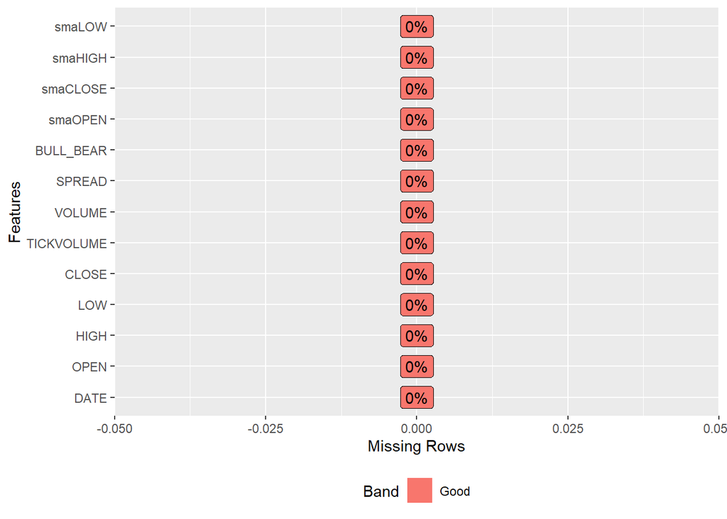

```r
plot_missing(CleanSet)
```

```r
View(CleanSet)
str(CleanSet)
```

```
## 'data.frame':    1029 obs. of  13 variables:
##  $ DATE      : chr  "2018.03.14" "2018.03.15" "2018.03.16" "2018.03.19" ...
##  $ OPEN      : num  1.24 1.24 1.23 1.23 1.23 ...
##  $ HIGH      : num  1.24 1.24 1.23 1.24 1.24 ...
##  $ LOW       : num  1.23 1.23 1.23 1.23 1.22 ...
##  $ CLOSE     : num  1.24 1.23 1.23 1.23 1.22 ...
##  $ TICKVOLUME: int  132189 139664 110331 117506 111873 145129 150537 125138 111194 124710 ...
##  $ VOLUME    : int  0 0 0 0 0 0 0 0 0 0 ...
##  $ SPREAD    : int  1 1 1 1 1 1 1 1 1 1 ...
##  $ BULL_BEAR : int  0 0 0 1 0 1 0 1 1 0 ...
##  $ smaOPEN   : num  1.23 1.23 1.23 1.23 1.23 ...
##  $ smaCLOSE  : num  1.23 1.23 1.23 1.23 1.23 ...
##  $ smaHIGH   : num  1.24 1.24 1.24 1.24 1.24 ...
##  $ smaLOW    : num  1.23 1.23 1.23 1.23 1.23 ...
##  - attr(*, "na.action")= 'omit' Named int [1:9] 1 2 3 4 5 6 7 8 9
##   ..- attr(*, "names")= chr [1:9] "1" "2" "3" "4" ...
```

```r
CleanSet$TICKVOLUME = as.numeric(as.integer(CleanSet$TICKVOLUME))
CleanSet$VOLUME = as.numeric(as.integer(CleanSet$VOLUME))
CleanSet$SPREAD = as.numeric(as.integer(CleanSet$SPREAD))
CleanSet$BULL_BEAR = as.numeric(as.integer(CleanSet$BULL_BEAR))
str(CleanSet)
```

```
## 'data.frame':    1029 obs. of  13 variables:
##  $ DATE      : chr  "2018.03.14" "2018.03.15" "2018.03.16" "2018.03.19" ...
##  $ OPEN      : num  1.24 1.24 1.23 1.23 1.23 ...
##  $ HIGH      : num  1.24 1.24 1.23 1.24 1.24 ...
##  $ LOW       : num  1.23 1.23 1.23 1.23 1.22 ...
##  $ CLOSE     : num  1.24 1.23 1.23 1.23 1.22 ...
##  $ TICKVOLUME: num  132189 139664 110331 117506 111873 ...
##  $ VOLUME    : num  0 0 0 0 0 0 0 0 0 0 ...
##  $ SPREAD    : num  1 1 1 1 1 1 1 1 1 1 ...
##  $ BULL_BEAR : num  0 0 0 1 0 1 0 1 1 0 ...
##  $ smaOPEN   : num  1.23 1.23 1.23 1.23 1.23 ...
##  $ smaCLOSE  : num  1.23 1.23 1.23 1.23 1.23 ...
##  $ smaHIGH   : num  1.24 1.24 1.24 1.24 1.24 ...
##  $ smaLOW    : num  1.23 1.23 1.23 1.23 1.23 ...
##  - attr(*, "na.action")= 'omit' Named int [1:9] 1 2 3 4 5 6 7 8 9
##   ..- attr(*, "names")= chr [1:9] "1" "2" "3" "4" ...
```

#### Univariate Analyses for market Features

*Evaluating standard deviation and kurtosis for each feature

```r
library(moments)#A library to visualize our  features

#Histogram for Open
print(paste0("standard deviation: ", sd(CleanSet$OPEN)))
print(paste0("Kurtosis: ", round(kurtosis(CleanSet$OPEN),2)))

options(repr.plot.width = 4, repr.plot.height = 4)
hist(CleanSet$OPEN, breaks=100, prob=TRUE) # Make it a probability distribution

m<-mean(CleanSet$OPEN)
std<-sqrt


#Histogram for High
print(paste0("standard deviation: ", sd(CleanSet$HIGH)))
print(paste0("Kurtosis: ", round(kurtosis(CleanSet$HIGH),2)))

options(repr.plot.width = 4, repr.plot.height = 4)
hist(CleanSet$HIGH, breaks=100, prob=TRUE) # Make it a probability distribution

m<-mean(CleanSet$HIGH)
std<-sqrt(var(CleanSet$HIGH))


#Histogram for Low
print(paste0("standard deviation: ", sd(CleanSet$LOW)))
print(paste0("Kurtosis: ", round(kurtosis(CleanSet$LOW),2)))

options(repr.plot.width = 4, repr.plot.height = 4)
hist(CleanSet$LOW, breaks=100, prob=TRUE) # Make it a probability distribution

m<-mean(CleanSet$LOW)
std<-sqrt(var(CleanSet$LOW))


#Histogram for Close
print(paste0("standard deviation: ", sd(CleanSet$CLOSE)))
print(paste0("Kurtosis: ", round(kurtosis(CleanSet$CLOSE),2)))

options(repr.plot.width = 4, repr.plot.height = 4)
hist(CleanSet$CLOSE, breaks=100, prob=TRUE) # Make it a probability distribution

m<-mean(CleanSet$CLOSE)
std<-sqrt(var(CleanSet$CLOSE))


#Histogram for TickVolume
print(paste0("standard deviation: ", sd(CleanSet$TICKVOLUME)))
print(paste0("Kurtosis: ", round(kurtosis(CleanSet$TICKVOLUME),2)))

options(repr.plot.width = 4, repr.plot.height = 4)
hist(CleanSet$TICKVOLUME, breaks=100, prob=TRUE) # Make it a probability distribution
m<-mean(CleanSet$TICKVOLUME)
std<-sqrt(var(CleanSet$TICKVOLUME))


#Histogram for Volume
print(paste0("standard deviation: ", sd(CleanSet$VOLUME)))
print(paste0("Kurtosis: ", round(kurtosis(CleanSet$VOLUME),2)))

options(repr.plot.width = 4, repr.plot.height = 4)
hist(CleanSet$VOLUME, breaks=100, prob=TRUE) # Make it a probability distribution

m<-mean(CleanSet$VOLUME)
std<-sqrt(var(CleanSet$VOLUME))


#Histogram for Spread
print(paste0("standard deviation: ", sd(CleanSet$SPREAD)))
print(paste0("Kurtosis: ", round(kurtosis(CleanSet$SPREAD),2)))

options(repr.plot.width = 4, repr.plot.height = 4)
hist(CleanSet$SPREAD, breaks=100, prob=TRUE) # Make it a probability distribution

m<-mean(CleanSet$SPREAD)
std<-sqrt(var(CleanSet$SPREAD))


#Histogram for Bull_Bear
print(paste0("standard deviation: ", sd(CleanSet$BULL_BEAR)))
print(paste0("Kurtosis: ", round(kurtosis(CleanSet$BULL_BEAR),2)))

options(repr.plot.width = 4, repr.plot.height = 4)
hist(CleanSet$BULL_BEAR, breaks=100, prob=TRUE) # Make it a probability distribution

m<-mean(CleanSet$BULL_BEAR)
std<-sqrt(var(CleanSet$BULL_BEAR))


#Histogram for smaOpen
print(paste0("standard deviation: ", sd(CleanSet$smaOPEN)))
print(paste0("Kurtosis: ", round(kurtosis(CleanSet$smaOPEN),2)))

options(repr.plot.width = 4, repr.plot.height = 4)
hist(CleanSet$smaOPEN, breaks=100, prob=TRUE) # Make it a probability distribution

m<-mean(CleanSet$smaOPEN)
std<-sqrt(var(CleanSet$smaOPEN))


#Histogram for smaHigh
print(paste0("standard deviation: ", sd(CleanSet$smaHIGH)))
print(paste0("Kurtosis: ", round(kurtosis(CleanSet$smaHigh),2)))

options(repr.plot.width = 4, repr.plot.height = 4)
hist(CleanSet$smaHIGH, breaks=100, prob=TRUE) # Make it a probability distribution

m<-mean(CleanSet$smaHigh)



#Histogram for smaLow
print(paste0("standard deviation: ", sd(CleanSet$smaLOW)))
print(paste0("Kurtosis: ", round(kurtosis(CleanSet$smaLOW),2)))

options(repr.plot.width = 4, repr.plot.height = 4)
hist(CleanSet$smaLOW, breaks=100, prob=TRUE) # Make it a probability distribution

m<-mean(CleanSet$smaLOW)
std<-sqrt(var(CleanSet$smaLOW))

#Histogram for smaClose

print(paste0("standard deviation: ", sd(CleanSet$smaCLOSE)))
print(paste0("Kurtosis: ", round(kurtosis(CleanSet$smaCLOSE),2)))

options(repr.plot.width = 4, repr.plot.height = 4)
hist(CleanSet$smaCLOSE, breaks=100, prob=TRUE) # Make it a probability distribution

m<-mean(CleanSet$smaCLOSE)
std<-sqrt(var(CleanSet$smaCLOSE))
# Overlay a standard normal distribution
curve(dnorm(x, mean=m, sd=std), col="darkblue", lwd=2, add=TRUE )
```

[output not shown]

#### Bivariate Analysis on the dataset

- 1.2. We go on to chart a scatterplot to see the effect of independent variables on the probability of BULL_BEAR

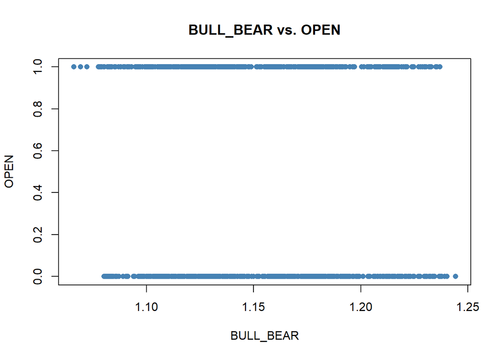

```r
library(ggplot2)#A library for plotting our scatterplot
#OPEN
plot(CleanSet$OPEN, CleanSet$BULL_BEAR, pch=16, col='steelblue',
     main='BULL_BEAR vs. OPEN',
     xlab='BULL_BEAR', ylab='OPEN')
```

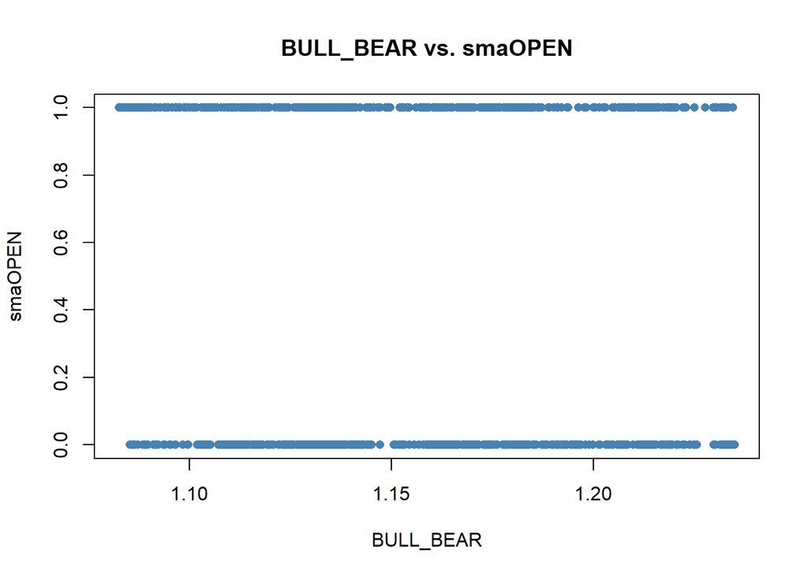

```r
#smaOPEN
plot(CleanSet$smaOPEN, CleanSet$BULL_BEAR, pch=16, col='steelblue',
     main='BULL_BEAR vs. smaOPEN',
     xlab='BULL_BEAR', ylab='smaOPEN')
```

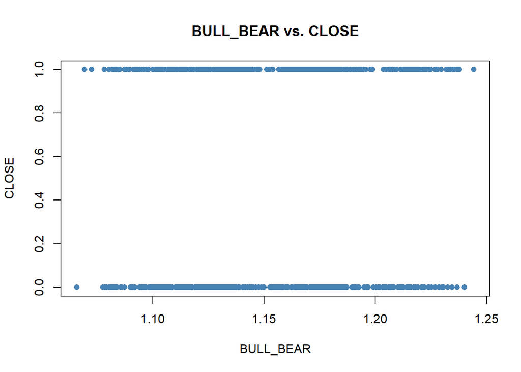

```r
#CLOSE
plot(CleanSet$CLOSE, CleanSet$BULL_BEAR, pch=16, col='steelblue',
     main='BULL_BEAR vs. CLOSE',
     xlab='BULL_BEAR', ylab='CLOSE')
```

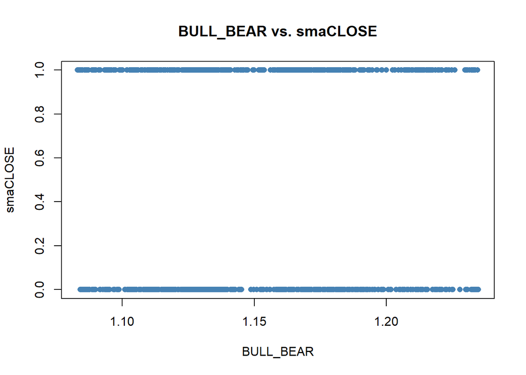

```r
#smaCLOSE
plot(CleanSet$smaCLOSE, CleanSet$BULL_BEAR, pch=16, col='steelblue',
     main='BULL_BEAR vs. smaCLOSE',
     xlab='BULL_BEAR', ylab='smaCLOSE')
```

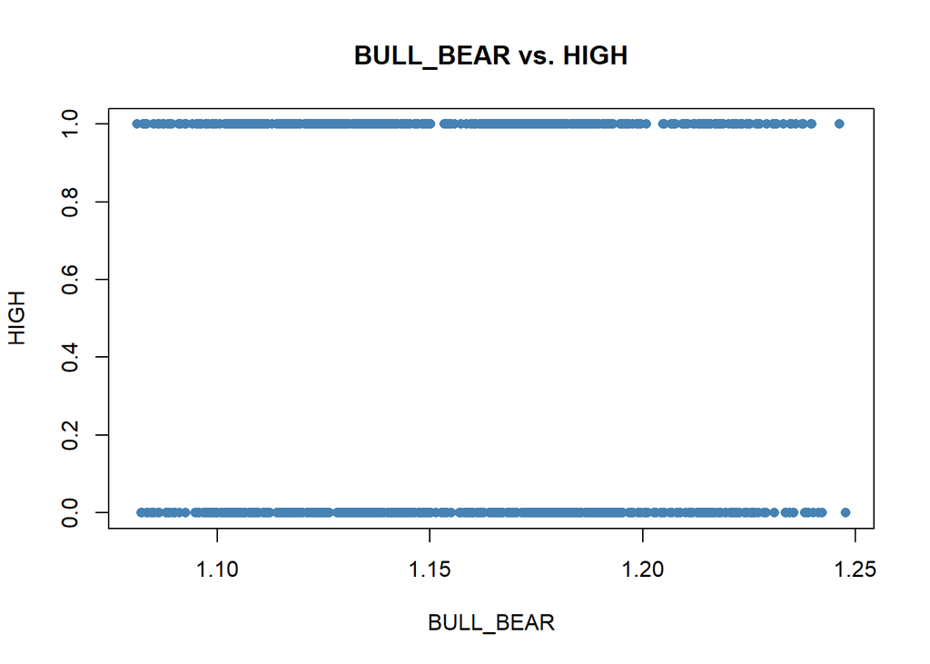

```r
#HIGH
plot(CleanSet$HIGH, CleanSet$BULL_BEAR, pch=16, col='steelblue',
     main='BULL_BEAR vs. HIGH',
     xlab='BULL_BEAR', ylab='HIGH')
```

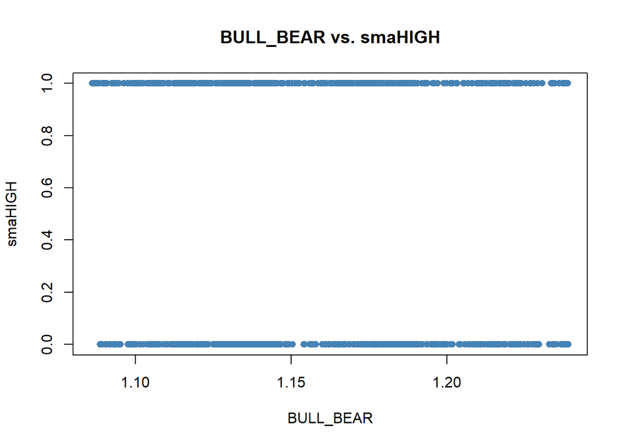

```r
#smaHIGH
plot(CleanSet$smaHIGH, CleanSet$BULL_BEAR, pch=16, col='steelblue',
     main='BULL_BEAR vs. smaHIGH',
     xlab='BULL_BEAR', ylab='smaHIGH')
```

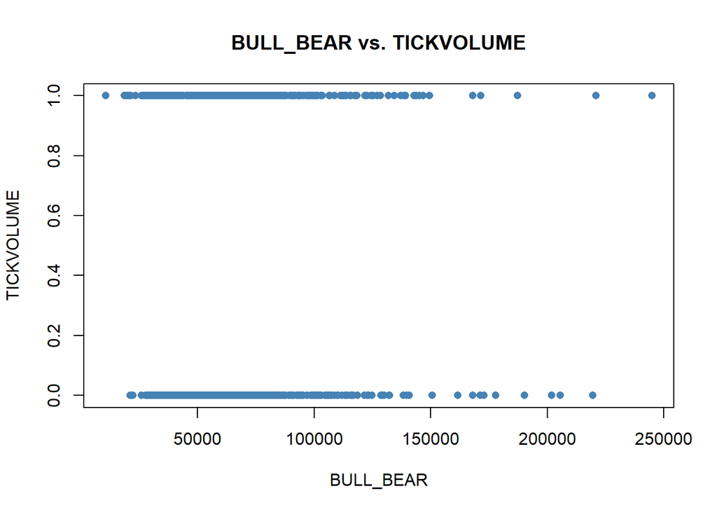

```r
#TICKVOLUME
plot(CleanSet$TICKVOLUME, CleanSet$BULL_BEAR, pch=16, col='steelblue',
     main='BULL_BEAR vs. TICKVOLUME',
     xlab='BULL_BEAR', ylab='TICKVOLUME')
```

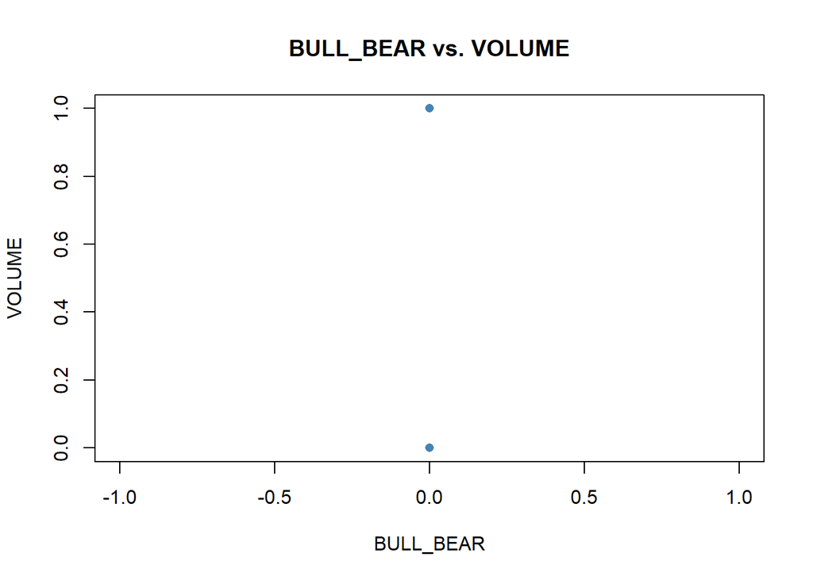

```r
#VOLUME
plot(CleanSet$VOLUME, CleanSet$BULL_BEAR, pch=16, col='steelblue',
     main='BULL_BEAR vs. VOLUME',
     xlab='BULL_BEAR', ylab='VOLUME')
```

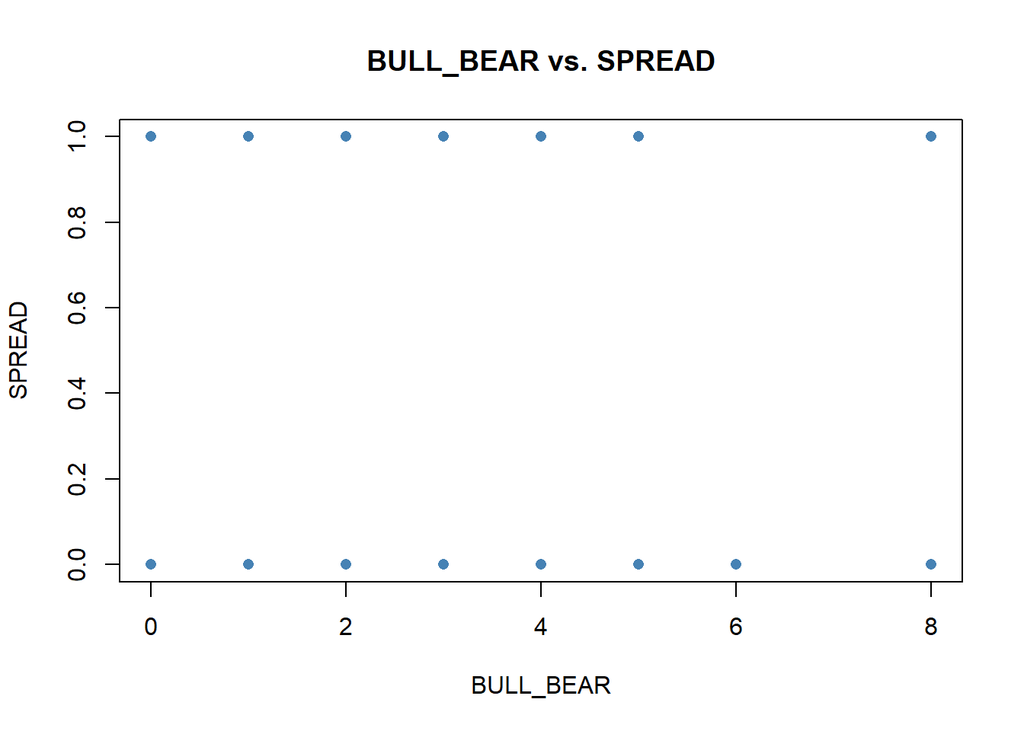

```r
#SPREAD
plot(CleanSet$SPREAD, CleanSet$BULL_BEAR, pch=16, col='steelblue',
     main='BULL_BEAR vs. SPREAD',
     xlab='BULL_BEAR', ylab='SPREAD')
```

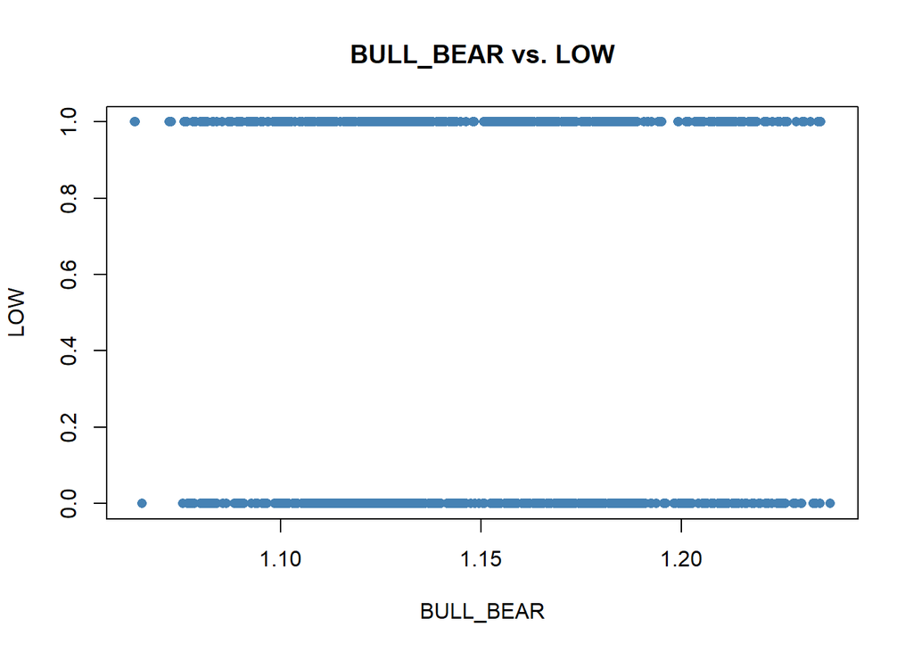

```r
#LOW
plot(CleanSet$LOW, CleanSet$BULL_BEAR, pch=16, col='steelblue',
     main='BULL_BEAR vs. LOW',
     xlab='BULL_BEAR', ylab='LOW')
```

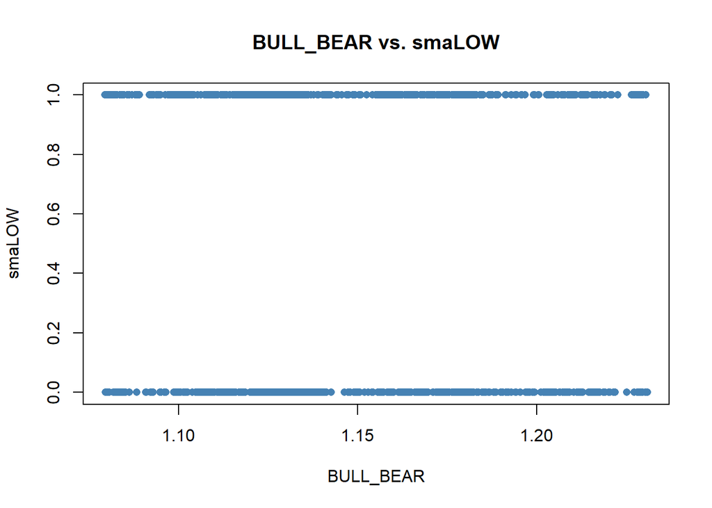

```r
#smaLOW
plot(CleanSet$smaLOW, CleanSet$BULL_BEAR, pch=16, col='steelblue',
     main='BULL_BEAR vs. smaLOW',
     xlab='BULL_BEAR', ylab='smaLOW')
```

```r
library(psych) # multivariate analysis
NewCleanSet = CleanSet[,-c(1,5,11)]#data set without date,close and smaCLOSE
corr.test(NewCleanSet)
```

```
## Call:corr.test(x = NewCleanSet)
## Correlation matrix
##             OPEN  HIGH   LOW TICKVOLUME VOLUME SPREAD BULL_BEAR smaOPEN smaHIGH
## OPEN        1.00  1.00  1.00       0.11     NA  -0.22     -0.05    0.98    0.98
## HIGH        1.00  1.00  1.00       0.14     NA  -0.22     -0.01    0.98    0.98
## LOW         1.00  1.00  1.00       0.08     NA  -0.22      0.00    0.98    0.98
## TICKVOLUME  0.11  0.14  0.08       1.00     NA   0.02     -0.03    0.14    0.16
## VOLUME        NA    NA    NA         NA     NA     NA        NA      NA      NA
## SPREAD     -0.22 -0.22 -0.22       0.02     NA   1.00     -0.01   -0.22   -0.22
## BULL_BEAR  -0.05 -0.01  0.00      -0.03     NA  -0.01      1.00   -0.04   -0.04
## smaOPEN     0.98  0.98  0.98       0.14     NA  -0.22     -0.04    1.00    1.00
## smaHIGH     0.98  0.98  0.98       0.16     NA  -0.22     -0.04    1.00    1.00
## smaLOW      0.98  0.98  0.98       0.12     NA  -0.21     -0.04    1.00    1.00
##            smaLOW
## OPEN         0.98
## HIGH         0.98
## LOW          0.98
## TICKVOLUME   0.12
## VOLUME         NA
## SPREAD      -0.21
## BULL_BEAR   -0.04
## smaOPEN      1.00
## smaHIGH      1.00
## smaLOW       1.00
## Sample Size
## [1] 1029
## Probability values (Entries above the diagonal are adjusted for multiple tests.)
##            OPEN HIGH  LOW TICKVOLUME VOLUME SPREAD BULL_BEAR smaOPEN smaHIGH
## OPEN        0.0 0.00 0.00       0.00     NA   0.00      0.93       0       0
## HIGH        0.0 0.00 0.00       0.00     NA   0.00      1.00       0       0
## LOW         0.0 0.00 0.00       0.10     NA   0.00      1.00       0       0
## TICKVOLUME  0.0 0.00 0.01       0.00     NA   1.00      1.00       0       0
## VOLUME       NA   NA   NA         NA     NA     NA        NA      NA      NA
## SPREAD      0.0 0.00 0.00       0.45     NA   0.00      1.00       0       0
## BULL_BEAR   0.1 0.86 0.89       0.38     NA   0.75      0.00       1       1
## smaOPEN     0.0 0.00 0.00       0.00     NA   0.00      0.17       0       0
## smaHIGH     0.0 0.00 0.00       0.00     NA   0.00      0.21       0       0
## smaLOW      0.0 0.00 0.00       0.00     NA   0.00      0.21       0       0
##            smaLOW
## OPEN            0
## HIGH            0
## LOW             0
## TICKVOLUME      0
## VOLUME         NA
## SPREAD          0
## BULL_BEAR       1
## smaOPEN         0
## smaHIGH         0
## smaLOW          0
##
##  To see confidence intervals of the correlations, print with the short=FALSE option
```

#### Correlation test findings

- All variables showed very low correlation to BULL_BEAR
- 1.69. Check significance of correlations

```r
# Check the correlation significance levels

cor.test(NewCleanSet$BULL_BEAR,NewCleanSet$OPEN)$p.value
```

```
## [1] 0.1037031
```

```r
cor.test(NewCleanSet$BULL_BEAR,NewCleanSet$HIGH)$p.value
```

```
## [1] 0.862107
```

```r
cor.test(NewCleanSet$BULL_BEAR,NewCleanSet$LOW)$p.value
```

```
## [1] 0.8875907
```

```r
cor.test(NewCleanSet$BULL_BEAR,NewCleanSet$TICKVOLUME)$p.value
```

```
## [1] 0.3845837
```

```r
cor.test(NewCleanSet$BULL_BEAR,NewCleanSet$VOLUME)$p.value
```

```
## [1] NA
```

```r
cor.test(NewCleanSet$BULL_BEAR,NewCleanSet$SPREAD)$p.value
```

```
## [1] 0.749039
```

```r
cor.test(NewCleanSet$BULL_BEAR,NewCleanSet$smaOPEN)$p.value
```

```
## [1] 0.1703079
```

```r
cor.test(NewCleanSet$BULL_BEAR,NewCleanSet$smaHIGH)$p.value
```

```
## [1] 0.2094101
```

```r
cor.test(NewCleanSet$BULL_BEAR,NewCleanSet$smaLOW)$p.value
```

```
## [1] 0.2050312
```

### 2.0. Machine Learning Analysis

- 2.1. Load mlbench and caret packages respectively
- 2.2. Ensure that dependent variable “BULL_BEAR” is of the factor class

```r
library(mlbench)
library(caret)
str(NewCleanSet)
```

```
## 'data.frame':    1029 obs. of  10 variables:
##  $ OPEN      : num  1.24 1.24 1.23 1.23 1.23 ...
##  $ HIGH      : num  1.24 1.24 1.23 1.24 1.24 ...
##  $ LOW       : num  1.23 1.23 1.23 1.23 1.22 ...
##  $ TICKVOLUME: num  132189 139664 110331 117506 111873 ...
##  $ VOLUME    : num  0 0 0 0 0 0 0 0 0 0 ...
##  $ SPREAD    : num  1 1 1 1 1 1 1 1 1 1 ...
##  $ BULL_BEAR : num  0 0 0 1 0 1 0 1 1 0 ...
##  $ smaOPEN   : num  1.23 1.23 1.23 1.23 1.23 ...
##  $ smaHIGH   : num  1.24 1.24 1.24 1.24 1.24 ...
##  $ smaLOW    : num  1.23 1.23 1.23 1.23 1.23 ...
```

```r
sapply(NewCleanSet,class)
```

```
##       OPEN       HIGH        LOW TICKVOLUME     VOLUME     SPREAD  BULL_BEAR
##  "numeric"  "numeric"  "numeric"  "numeric"  "numeric"  "numeric"  "numeric"
##    smaOPEN    smaHIGH     smaLOW
##  "numeric"  "numeric"  "numeric"
```

```r
NewCleanSet$BULL_BEAR = as.factor(as.integer(NewCleanSet$BULL_BEAR))
summary(NewCleanSet)
```

```
##       OPEN            HIGH            LOW          TICKVOLUME         VOLUME
##  Min.   :1.066   Min.   :1.081   Min.   :1.064   Min.   : 10530   Min.   :0
##  1st Qu.:1.121   1st Qu.:1.125   1st Qu.:1.118   1st Qu.: 48674   1st Qu.:0
##  Median :1.144   Median :1.148   Median :1.140   Median : 60593   Median :0
##  Mean   :1.152   Mean   :1.155   Mean   :1.148   Mean   : 65884   Mean   :0
##  3rd Qu.:1.181   3rd Qu.:1.185   3rd Qu.:1.178   3rd Qu.: 77509   3rd Qu.:0
##  Max.   :1.244   Max.   :1.248   Max.   :1.237   Max.   :244937   Max.   :0
##      SPREAD      BULL_BEAR    smaOPEN         smaHIGH          smaLOW
##  Min.   :0.000   0:523     Min.   :1.083   Min.   :1.086   Min.   :1.079
##  1st Qu.:0.000   1:506     1st Qu.:1.123   1st Qu.:1.126   1st Qu.:1.119
##  Median :1.000             Median :1.144   Median :1.148   Median :1.140
##  Mean   :1.134             Mean   :1.152   Mean   :1.156   Mean   :1.149
##  3rd Qu.:2.000             3rd Qu.:1.182   3rd Qu.:1.185   3rd Qu.:1.178
##  Max.   :8.000             Max.   :1.235   Max.   :1.239   Max.   :1.231
```

- 2.3. Perform feature selection. Correlation analyses findings in Section 1 already pointed to the fact that some features have no association with the outcome of the dependent variable.
- 2.4. Feature Selection using Boruta, mlbench and Caret packages respectively

```r
library(Boruta)
# Feature Selection operation
set.seed(7)
boruta = Boruta(NewCleanSet$BULL_BEAR~.,data = NewCleanSet, doTrace = 4, maxRuns = 100)
```

[output not shown]

[output not shown]

[output not shown]

[output not shown]

[output not shown]

[output not shown]

[output not shown]

[output not shown]

[output not shown]

[output not shown]

[output not shown]

[output not shown]

[output not shown]

[output not shown]

[output not shown]

[output not shown]

[output not shown]

[output not shown]

[output not shown]

[output not shown]

```
## After 10 iterations, +16 secs:
```

```
##  confirmed 2 attributes: OPEN, smaOPEN;
```

```
##  rejected 3 attributes: SPREAD, TICKVOLUME, VOLUME;
```

```
##  still have 4 attributes left.
```

[output not shown]

[output not shown]

[output not shown]

[output not shown]

[output not shown]

[output not shown]

[output not shown]

[output not shown]

```
## After 14 iterations, +23 secs:
```

```
##  confirmed 2 attributes: HIGH, LOW;
```

```
##  still have 2 attributes left.
```

[output not shown]

[output not shown]

[output not shown]

[output not shown]

[output not shown]

[output not shown]

[output not shown]

[output not shown]

[output not shown]

[output not shown]

[output not shown]

[output not shown]

[output not shown]

[output not shown]

[output not shown]

[output not shown]

[output not shown]

[output not shown]

[output not shown]

[output not shown]

[output not shown]

[output not shown]

[output not shown]

[output not shown]

[output not shown]

[output not shown]

```
## After 27 iterations, +47 secs:
```

```
##  rejected 1 attribute: smaHIGH;
```

```
##  still have 1 attribute left.
```

[output not shown]

[output not shown]

[output not shown]

[output not shown]

[output not shown]

[output not shown]

[output not shown]

[output not shown]

[output not shown]

[output not shown]

[output not shown]

[output not shown]

[output not shown]

[output not shown]

[output not shown]

[output not shown]

[output not shown]

[output not shown]

[output not shown]

[output not shown]

[output not shown]

[output not shown]

[output not shown]

[output not shown]

[output not shown]

[output not shown]

[output not shown]

[output not shown]

[output not shown]

[output not shown]

[output not shown]

[output not shown]

[output not shown]

[output not shown]

[output not shown]

[output not shown]

[output not shown]

[output not shown]

[output not shown]

[output not shown]

[output not shown]

[output not shown]

[output not shown]

[output not shown]

[output not shown]

[output not shown]

[output not shown]

[output not shown]

[output not shown]

[output not shown]

[output not shown]

[output not shown]

[output not shown]

[output not shown]

[output not shown]

[output not shown]

[output not shown]

[output not shown]

[output not shown]

[output not shown]

[output not shown]

[output not shown]

[output not shown]

[output not shown]

[output not shown]

[output not shown]

[output not shown]

[output not shown]

[output not shown]

[output not shown]

[output not shown]

[output not shown]

[output not shown]

[output not shown]

```
## After 64 iterations, +1.8 mins:
```

```
##  confirmed 1 attribute: smaLOW;
```

```
##  no more attributes left.
```

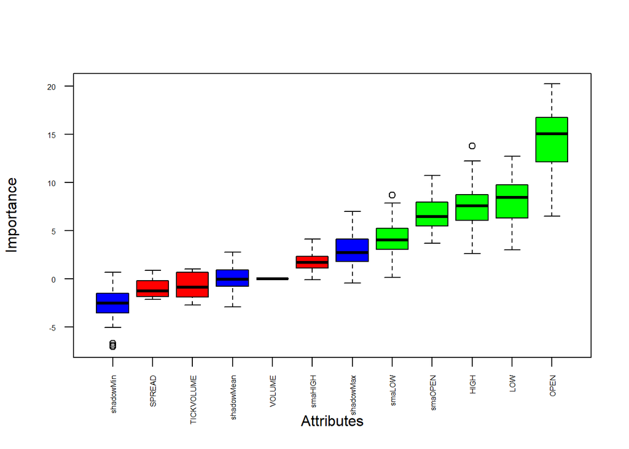

```r
plot(boruta, las = 2, cex.axis = 0.5)

# reclassify features that were designated as tentative
bor = TentativeRoughFix(boruta)
plot(bor, las = 2, cex.axis = 0.5)
```

```r
attStats(boruta)
```

```
##               meanImp  medianImp      minImp     maxImp normHits  decision
## OPEN       14.4539657 15.0410604  6.52390319 20.2273746 1.000000 Confirmed
## HIGH        7.5611494  7.6048435  2.63591591 13.7883539 0.968750 Confirmed
## LOW         7.9961717  8.4429345  3.01865854 12.7167331 0.984375 Confirmed
## TICKVOLUME -0.7695298 -0.8519079 -2.72513038  1.0496597 0.000000  Rejected
## VOLUME      0.0000000  0.0000000  0.00000000  0.0000000 0.000000  Rejected
## SPREAD     -0.9927766 -1.2296616 -2.14120188  0.9103618 0.000000  Rejected
## smaOPEN     6.7074732  6.4550699  3.70147135 10.7141618 0.984375 Confirmed
## smaHIGH     1.7248444  1.7367231 -0.08251383  4.1362987 0.078125  Rejected
## smaLOW      4.1154271  4.0382087  0.15384600  8.7231180 0.703125 Confirmed
```

```r
print(bor)
```

```
## Boruta performed 64 iterations in 1.75654 mins.
##  5 attributes confirmed important: HIGH, LOW, OPEN, smaLOW, smaOPEN;
##  4 attributes confirmed unimportant: smaHIGH, SPREAD, TICKVOLUME,
## VOLUME;
```

```r
# create object and limit features to only the 5 confirmed features from the boruta analysis + the dependent variable

col_order2 = c("OPEN","HIGH","LOW","smaOPEN","smaLOW","BULL_BEAR")

NewSet = NewCleanSet[, col_order2]
View(NewSet)
str(NewSet)
```

```
## 'data.frame':    1029 obs. of  6 variables:
##  $ OPEN     : num  1.24 1.24 1.23 1.23 1.23 ...
##  $ HIGH     : num  1.24 1.24 1.23 1.24 1.24 ...
##  $ LOW      : num  1.23 1.23 1.23 1.23 1.22 ...
##  $ smaOPEN  : num  1.23 1.23 1.23 1.23 1.23 ...
##  $ smaLOW   : num  1.23 1.23 1.23 1.23 1.23 ...
##  $ BULL_BEAR: Factor w/ 2 levels "0","1": 1 1 1 2 1 2 1 2 2 1 ...
```

```r
levels(NewSet)
```

[output not shown]

- The feature selection operation using the Boruta package works as follows:
- Firstly, it introduces randomness into the data set by producing shuffled copies of all the features of interest (these are referred to as shadow features).
- Next, it trains a random forest classifier on the extended data set and applies a feature importance measure (the default is Mean Decrease Accuracy) to ascertain the relevance of each of the features. Those with higher means are classified as more important.
- Afterwards, at every given iteration, it checks whether a real feature has a higher importance than the best of its shadow features (in other words, it checks to see if the feature has a higher Z-score than the maximum Z-score of its shadow features) and therefore eliminates features which are termed highly irrelevant.
- Lastly, the Boruta algorithm stops either when all features gets confirmed or rejected or when it reaches a specified limit of random forest runs
- 2.5. Split the NewSet features object into training and validation groups (objects)
- 2.6. Split out validation dataset
- 2.7. Do this by creating a list of 70% of the rows in the original dataset to serve as training set

```r
#LOW/BEARISH TREND
LOW = NewSet[NewSet$BULL_BEAR == 0,]

#HIGH/BULLISH TREND
HIGH = NewSet[NewSet$BULL_BEAR == 1,]

set.seed(7)
validationIndex = createDataPartition(NewSet$BULL_BEAR , p=0.70, list = FALSE)

#select 30% of the data for validation

validation = NewSet[-validationIndex,]

#use the remaining 70% of data to train the model
dataset = NewSet[validationIndex,]

# Check that the distribution of the dependent variable is similar in train and test sets
prop.table(table(NewSet$BULL_BEAR))
```

```
##
##         0         1
## 0.5082604 0.4917396
```

```r
prop.table(table(dataset$BULL_BEAR))
```

```
##
##         0         1
## 0.5083102 0.4916898
```

```r
prop.table(table(validation$BULL_BEAR))
```

```
##
##         0         1
## 0.5081433 0.4918567
```

- The derived figures show that the ratio of the “LOW”:“HIGH” was proportionally split
- 2.8. Evaluate 8 Machine Learning Algorithms using our Historical forex data
- 2.9. Linear Algorithms - Generalized linear model (LG) and Linear Discriminate Analysis (LDA)
- 2.9.1 Non-Linear Algorithms - K-Nearest Neighbors (KNN),Support Vector Machine(SVM), Neural Network(pcaNNEt),Multiple Layer Perceptron(MLP)
- 2.9.2 ENSEMBLE METHODS: Random Forest (RF), Naive Bayes,
- 2.9.3 Analysis is done using 10-fold cross validation with 3 repeats

```r
trainControl = trainControl(method = "repeatedcv", number = 10, repeats = 3)
metric = "Accuracy"

#1 LG
set.seed(7)
fit.glm = train(BULL_BEAR~., data=dataset, method="glm", metric=metric, trControl=trainControl)

#2 LDA
set.seed(7)
fit.lda = train(BULL_BEAR~., data=dataset, method="lda", metric=metric, trControl=trainControl)

#3 KNN
set.seed(7)
fit.knn = train(BULL_BEAR~., data=dataset, method="knn", metric=metric, trControl=trainControl)


#4 Random Forest
set.seed(7)
fit.rf = train(BULL_BEAR~., data=dataset, method="rf", metric=metric, trControl=trainControl)

#5 SVM
set.seed(7)
fit.svmLinear = train(BULL_BEAR~., data=dataset, method="svmLinear", metric=metric, trControl=trainControl)

#6 Naive Bayes
set.seed(7)
fit.naive_bayes = train(BULL_BEAR~., data=dataset, method="naive_bayes", metric=metric, trControl=trainControl)

#7 Multi Layer Perceptron
set.seed(7)
fit.mlp = train(BULL_BEAR~., data=dataset, method="mlp", metric=metric, trControl=trainControl)

#8 Neural Network
set.seed(7)
fit.pcaNNet = train(BULL_BEAR~., data=dataset, method="pcaNNet", metric=metric, trControl=trainControl)
# Compare algorithms
results = resamples(list(LG=fit.glm, LDA=fit.lda, KNN=fit.knn,RF=fit.rf,  SVM=fit.svmLinear, NB = fit.naive_bayes, MLP = fit.mlp, NN=fit.pcaNNet))

summary(results)
```

```
##
## Call:
## summary.resamples(object = results)
##
## Models: LG, LDA, KNN, RF, SVM, NB, MLP, NN
## Number of resamples: 30
##
## Accuracy
##          Min.   1st Qu.    Median      Mean   3rd Qu.      Max. NA's
## LG  0.7605634 0.8247717 0.8741197 0.8628350 0.8904110 0.9452055    0
## LDA 0.7808219 0.8247717 0.8620624 0.8618833 0.8900304 0.9452055    0
## KNN 0.5277778 0.5773402 0.6224570 0.6235531 0.6527778 0.7671233    0
## RF  0.5694444 0.6849315 0.7103311 0.7127464 0.7447907 0.8493151    0
## SVM 0.7777778 0.8090278 0.8461463 0.8416074 0.8745599 0.9041096    0
## NB  0.4166667 0.4794521 0.5205479 0.5157415 0.5473885 0.6301370    0
## MLP 0.4861111 0.4931507 0.5068493 0.5037039 0.5070423 0.5555556    0
## NN  0.4583333 0.5205479 0.5486205 0.5456702 0.5694444 0.6388889    0
##
## Kappa
##            Min.     1st Qu.     Median        Mean    3rd Qu.      Max. NA's
## LG   0.52046087  0.64938449 0.74807138 0.725546661 0.78069837 0.8903080    0
## LDA  0.56090226  0.64919203 0.72420188 0.723574827 0.77990650 0.8903080    0
## KNN  0.05918524  0.15303567 0.24455035 0.246377868 0.30448223 0.5343340    0
## RF   0.14285714  0.36962636 0.42071607 0.425197509 0.48913046 0.6984604    0
## SVM  0.55452436  0.61791602 0.69267047 0.682994700 0.74913229 0.8083990    0
## NB  -0.17118513 -0.04227039 0.04058797 0.031177078 0.09517909 0.2587439    0
## MLP  0.00000000  0.00000000 0.00000000 0.003496503 0.00000000 0.1048951    0
## NN  -0.08500773  0.03856998 0.09554140 0.089260834 0.13421100 0.2777778    0
```

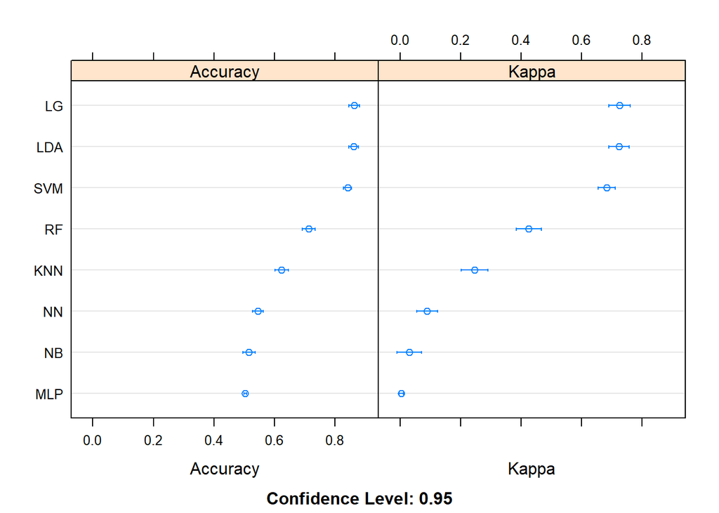

```r
dotplot(results)
```

####* Top three performing algorithms are LG,LDA SVM, with mean accuracies of 0.8628, 0.8619 and 0.8416 respectively

#### Tune the top two learning algorithms

- 4.18. Tuning for the LG learning algorithm

```r
trainControl = trainControl(method="repeatedcv", number=10, repeats=3)
metric = "Accuracy"

#LG
set.seed(7)
grid = expand.grid(.parameter = seq(1,10, by=1))
fit.LG_tuned = train(BULL_BEAR~.,data = dataset, method="glm", metric=metric, tuneGrid=grid, trControl=trainControl)
fit.LG_tuned
```

```
## Generalized Linear Model
##
## 722 samples
##   5 predictor
##   2 classes: '0', '1'
##
## No pre-processing
## Resampling: Cross-Validated (10 fold, repeated 3 times)
## Summary of sample sizes: 650, 650, 649, 649, 650, 651, ...
## Resampling results across tuning parameters:
##
##   Accuracy  Kappa      parameter
##   0.862835  0.7255467  1
##   0.862835  0.7255467  1
##   0.862835  0.7255467  1
##   0.862835  0.7255467  1
##   0.862835  0.7255467  1
##   0.862835  0.7255467  1
##   0.862835  0.7255467  1
##   0.862835  0.7255467  1
##   0.862835  0.7255467  1
##   0.862835  0.7255467  1
##
## Accuracy was used to select the optimal model using the largest value.
## The final value used for the model was parameter = 1.
```

- Tuning did not improve the LG model
- 4.19. Tuning for the LDA learning algorithm

```r
trainControl = trainControl(method="repeatedcv", number=10, repeats=3)
metric = "Accuracy"

#LDA
set.seed(7)
grid = expand.grid(.parameter = seq(1,10, by=1))
fit.lda_tuned = train(BULL_BEAR~.,data = dataset, method="lda", metric=metric, tuneGrid=grid, trControl=trainControl)
fit.lda_tuned
```

```
## Linear Discriminant Analysis
##
## 722 samples
##   5 predictor
##   2 classes: '0', '1'
##
## No pre-processing
## Resampling: Cross-Validated (10 fold, repeated 3 times)
## Summary of sample sizes: 650, 650, 649, 649, 650, 651, ...
## Resampling results across tuning parameters:
##
##   Accuracy   Kappa      parameter
##   0.8618833  0.7235748  1
##   0.8618833  0.7235748  1
##   0.8618833  0.7235748  1
##   0.8618833  0.7235748  1
##   0.8618833  0.7235748  1
##   0.8618833  0.7235748  1
##   0.8618833  0.7235748  1
##   0.8618833  0.7235748  1
##   0.8618833  0.7235748  1
##   0.8618833  0.7235748  1
##
## Accuracy was used to select the optimal model using the largest value.
## The final value used for the model was parameter = 1.
```

- Tuning did not improve the LDA model
- 3. Finalize by building Model using LG
- 3.1. Prepare the data transform for finalizing Model

```r
set.seed(7)
x = dataset[,1:6]
preprocessParam = preProcess(x)
x = predict(preprocessParam, x)

# prepare the validation dataset
set.seed(7)

# transform the validation dataset
validationX = predict(preprocessParam, validation[,1:6])
```

- 3.2. Make predictions and build confusion matrix for Model 1

```r
glmPredict = predict(fit.glm, newdata = validation)
confusionMatrix(glmPredict, validation$BULL_BEAR)
```

```
## Confusion Matrix and Statistics
##
##           Reference
## Prediction   0   1
##          0 135  19
##          1  21 132
##
##                Accuracy : 0.8697
##                  95% CI : (0.8268, 0.9053)
##     No Information Rate : 0.5081
##     P-Value [Acc > NIR] : <2e-16
##
##                   Kappa : 0.7394
##
##  Mcnemar's Test P-Value : 0.8744
##
##             Sensitivity : 0.8654
##             Specificity : 0.8742
##          Pos Pred Value : 0.8766
##          Neg Pred Value : 0.8627
##              Prevalence : 0.5081
##          Detection Rate : 0.4397
##    Detection Prevalence : 0.5016
##       Balanced Accuracy : 0.8698
##
##        'Positive' Class : 0
##
```

- Model performed at an accuracy of 0.8697 with a specificity of 0.8742 with a sensitivity score of 0.8654.
- 3.3. Calculate AUC(ROC) for Model 1

```r
library(PRROC)
sapply(glmPredict, class)
```

[output not shown]

[output cut: 24 more lines]

```r
sapply(validation, class)
```

```
##      OPEN      HIGH       LOW   smaOPEN    smaLOW BULL_BEAR
## "numeric" "numeric" "numeric" "numeric" "numeric"  "factor"
```

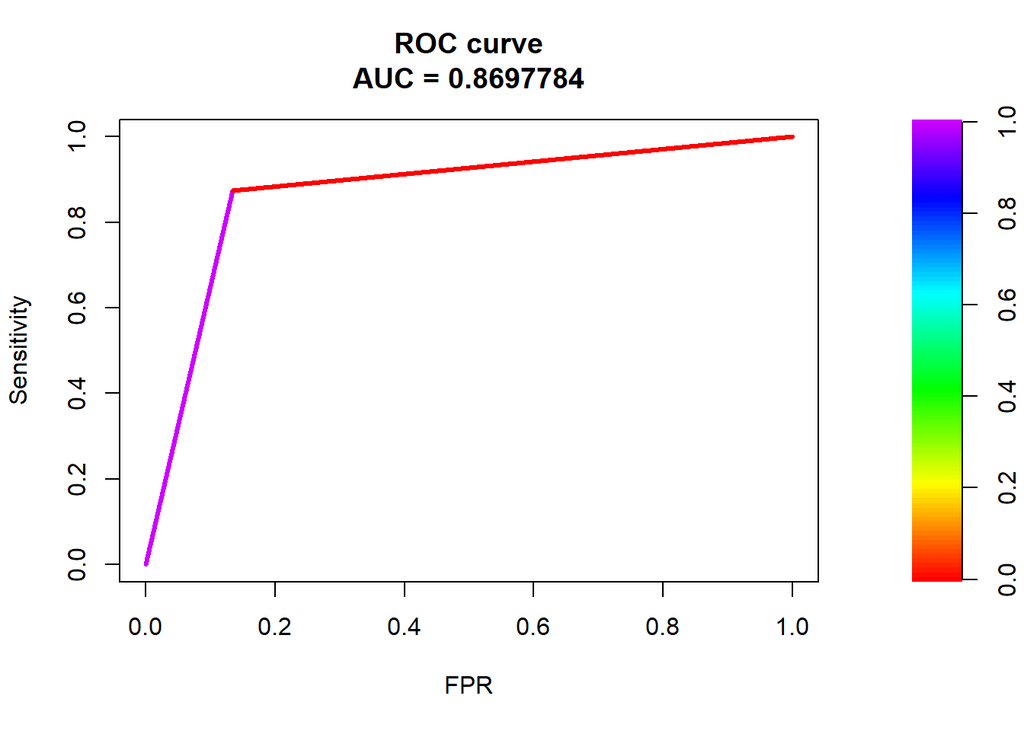

```r
pred = as.numeric(as.character(glmPredict))
valid = as.character(as.factor(validation$BULL_BEAR))
valid = as.numeric(as.character(validation$BULL_BEAR))
prroc_obj = roc.curve(scores.class0 = pred, weights.class0 = valid, curve = TRUE)
plot(prroc_obj)
```